# A Year of Cyclistic Bike-Share Trends

Rhiannon Eckinger-Seda

2022-09-08

**Statement of the Business Task**

The goal of the following analysis is to determine the differences between Cyclistic customers of two varieties: annual members whose membership grants unlimited rides and casual riders who purchase rides for individual trips, or day passes. The goal is to use the discerned differences to determine how Cyclistic can convert current customers from casual riders to annual members.

**Data Source Used**

The data analyzed is data Cyclistic collected and provided for the purpose of this analysis. The data was available to be accessed by month. This analysis utilized the most recent, complete, 12 months of data which covered August 2021 through July of 2022, as this project began in August of 2022. Data included: ride start and end times, ride start and end locations, the type of rideable, either a classic or electric bike, and whether the ride was accessed by an annual member or a casual rider.

The data identifying start and end locations contained numerous null values. For this reason, this information was removed and not used for analysis. All other null values were able to be removed while retaining the integrity of teh data.

**Cleaning the Data**

Several steps were taken to clean, or prepare the data for analysis.

1. Column names were matched across the 12 individual months using the colnames() function.
2. Data types were also matched using str().
3. The 12 individual months were then combined into one dataframe using bind_rows().

all_trips<-bind_rows(X202207_divvy_tripdata, X202206_divvy_tripdata, X202205_divvy_tripdata, X202204_divvy_tripdata,X202203_divvy_tripdata, X202202_divvy_tripdata, X202201_divvy_tripdata, X202112_divvy_tripdata, X202111_divvy_tripdata, X202110_divvy_tripdata, X202109_divvy_tripdata, X202108_divvy_tripdata)

4. A column was added, called ride_length, to calculate the length of each trip.

all_trips$ride_length<-difftime(all_trips$ended_at,all_trips$started_at)

5. Having the ride lengths, the data was able to be further cleaned to remove ride lengths of 0 or negative length, which indicate the ride was not completed by a customer and would not be relevant to this analysis.

**The Analysis**

Additional columns were created which broke the start time down into a month, day, year, and day of the week which allowed for ease of conducting analysis and calculations.

all_trips_v2$date <- as.Date(all_trips_v2$started_at) #The default format is yyyy-mm-dd all_trips_v2$month <- format(as.Date(all_trips_v2$date), “%m”) all_trips_v2$day <- format(as.Date(all_trips_v2$date), “%d”) all_trips_v2$year <- format(as.Date(all_trips_v2$date), “%Y”) all_trips_v2$day_of_week <- format(as.Date(all_trips_v2$date), “%A”)

aggregate(all_trips_v2$ride_length ~ all_trips_v2$member_casual + all_trips_v2$day_of_week)

By breaking the dates down, I was able to conduct analysis on the number of rides and ride lengths by members and casuals as they occurred across days of the week and the 12 months included in the analysis.

#The average ride length by casual riders and members:

all_trips_v5$member_casual all_trips_v5$ride_length 1 casual 1561.2778 secs 2 member 765.1921 secs >

```
#A tibble of the average ride lengths for casual riders and members by day of the week:

# A tibble: 14 × 4
# Groups:   member_casual [2]
   member_casual weekday number_of_rides average_duration
   <chr>         <ord>             <int> <drtn>
 1 casual        Sun              413620 1803.8231 secs
 2 casual        Mon              253640 1620.3128 secs
 3 casual        Tue              228431 1358.9221 secs
 4 casual        Wed              235605 1337.0481 secs
 5 casual        Thu              265095 1375.2556 secs
 6 casual        Fri              292850 1445.9036 secs
 7 casual        Sat              459120 1706.9035 secs
 8 member        Sun              354544  865.1998 secs
 9 member        Mon              404897  743.9893 secs
10 member        Tue              450650  717.2649 secs
11 member        Wed              449873  722.6226 secs
12 member        Thu              446615  732.2676 secs
13 member        Fri              395231  745.1750 secs
14 member        Sat              384794  860.0298 secs
```

find_mode <- function(x) { u <- unique(x) tab <- tabulate(match(x, u)) u[tab == max(tab)] } data <- c()

**Visualizations**

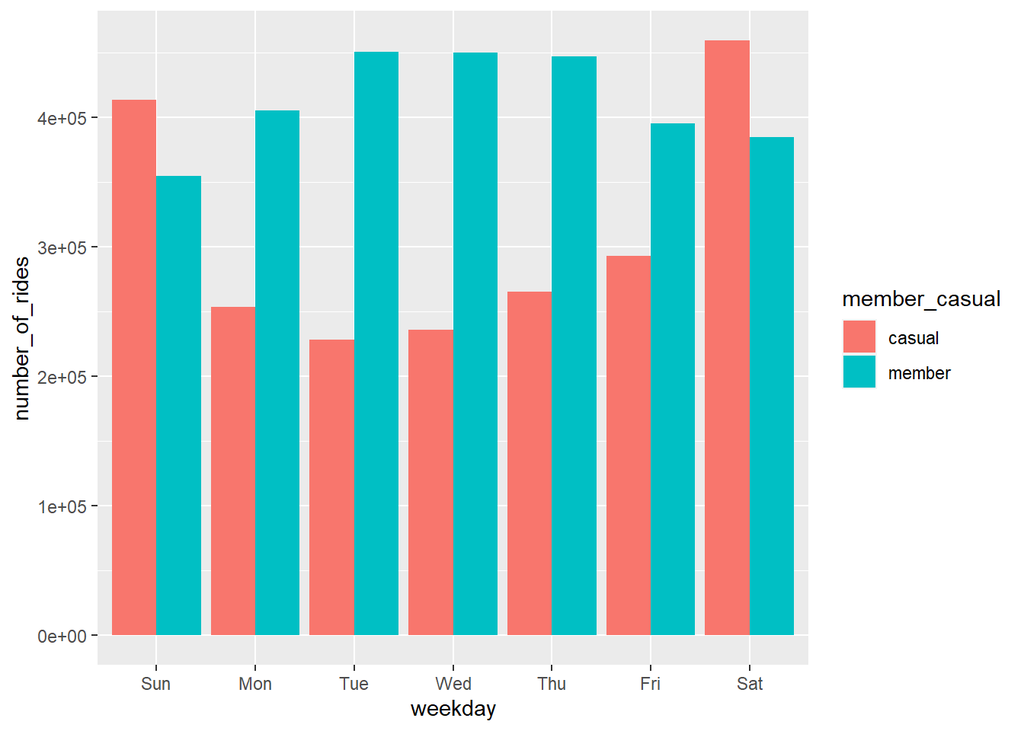

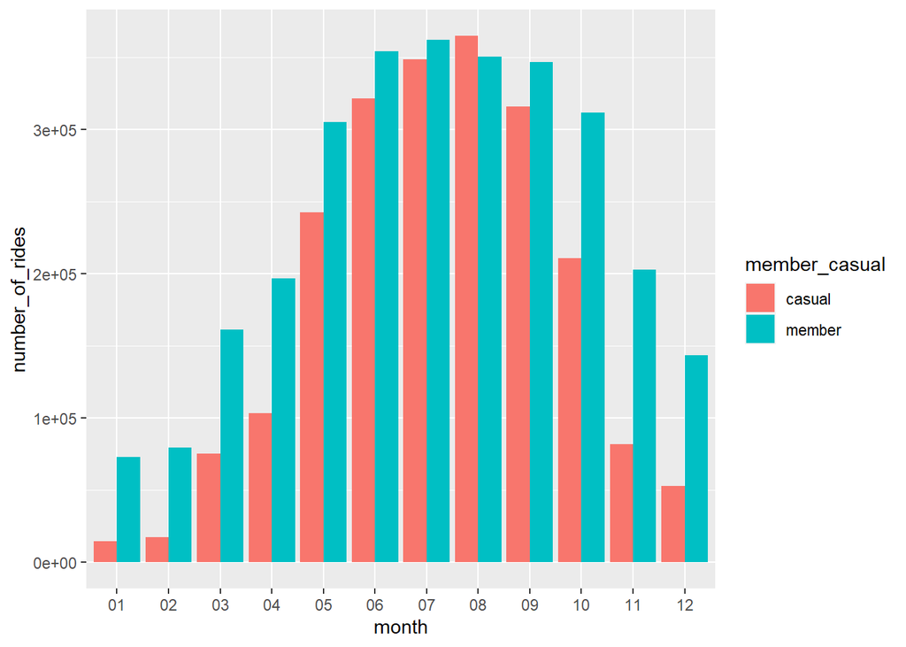

**Recommendations**

Based on analysis, my recommendations are as follows:

Focus advertising on the months of May through October. The visualization showing the number of rides taken each month indicate that significantly fewer rides are taken during the colder, snowy, rainy months, November through April, by both members and casual riders. It is, therefore, unlikely that more memberships will be purchased during this time by casual riders, no matter how effective the campaign.

Highlight the increase in accessibility provided by an annual membership, that Cyclistic has thousands of bikes available across the city. The data shows annual members take shorter rides, and take more rides Monday through Friday. Casual riders take longer rides, most commonly on weekends. This suggests members are more likely to be accessing Cyclistic bikes for commuting and errands, while casual riders are likely accessing bikes for leisure.